# PEC1 - Análisis de datos ómicos

```r
head(colData(SE))
```

```
## DataFrame with 6 rows and 6 columns
##     local_sample_id    study_id sample_source mb_sample_id    raw_data
##         <character> <character>   <character>  <character> <character>
## 1                 1    ST000284 Blood (serum)     SA012482
## 10               10    ST000284 Blood (serum)     SA012495
## 100             100    ST000284 Blood (serum)     SA012480
## 102             102    ST000284 Blood (serum)     SA012523
## 106             106    ST000284 Blood (serum)     SA012532
## 107             107    ST000284 Blood (serum)     SA012440
##     Patient_group
##          <factor>
## 1         Healthy
## 10        Polyp
## 100       Healthy
## 102       Polyp
## 106       Polyp
## 107       Healthy
```

```r
head(rowData(SE))
```

```
## DataFrame with 6 rows and 3 columns
##            metabolite_name metabolite_id            refmet_name
##                <character>   <character>            <character>
## ME102945 1-Methyladenosine      ME102945      1-Methyladenosine
## ME102946 1-Methylhistamine      ME102946      1-Methylhistamine
## ME102947    2-Aminoadipate      ME102947 alpha-Aminoadipic acid
## ME102948   2'-Deoxyuridine      ME102948           Deoxyuridine
## ME102949  3-Nitro-tyrosine      ME102949          Nitrotyrosine
## ME102950  4-Pyridoxic acid      ME102950       4-Pyridoxic acid
```

```r
summary(assay(SE))
```

[output not shown]

[output cut: 337 more lines]

```
##  Max.   :63365888   Max.   :75464820   Max.   :90012363   Max.   :72506181
##        79                 86                  87                 88
##  Min.   :    7500   Min.   :     2488   Min.   :    6167   Min.   :    1271
##  1st Qu.:   80364   1st Qu.:    76394   1st Qu.:   64535   1st Qu.:   57464
##  Median :  233683   Median :   303497   Median :  270152   Median :  241817
##  Mean   : 5001591   Mean   :  4917100   Mean   : 4113691   Mean   : 3632016
##  3rd Qu.: 2156940   3rd Qu.:  1818793   3rd Qu.: 1527386   3rd Qu.: 1517612
##  Max.   :80295589   Max.   :103150647   Max.   :83847135   Max.   :60241353
##        91                 93                 98                 99
##  Min.   :       1   Min.   :    1281   Min.   :       1   Min.   :       1
##  1st Qu.:   66224   1st Qu.:   71084   1st Qu.:   64530   1st Qu.:   64612
##  Median :  293231   Median :  353132   Median :  283962   Median :  257461
##  Mean   : 4206831   Mean   : 4223439   Mean   : 3316200   Mean   : 3955430
##  3rd Qu.: 1927273   3rd Qu.: 1733030   3rd Qu.: 1788282   3rd Qu.: 1827740
##  Max.   :59021330   Max.   :72099647   Max.   :55311748   Max.   :73642664
```

```r
# Estadísticas descriptivas por grupo
group_summary <- colData(SE) %>%
  as_tibble() %>%
  group_by(Patient_group) %>%
  summarise(n = n())

print(group_summary)
```

```
## # A tibble: 3 × 2
##   Patient_group     n
##   <fct>         <int>
## 1 CRC              64
## 2 Healthy          84
## 3 Polyp            76
```

Se realiza un PCA para reducir la dimensionalidad de los datos y ver cómo se distribuyen las muestras en función de las primeras componentes principales.

```r
# PCA
pca_result <- PCA(t(assay(SE)), graph = FALSE, scale.unit = TRUE)

# Varianza explicada
eigenvalue <- get_eigenvalue(pca_result)
head(eigenvalue)
```

```
##       eigenvalue variance.percent cumulative.variance.percent
## Dim.1  14.574781        12.898036                    12.89804
## Dim.2  10.415798         9.217520                    22.11556
## Dim.3   6.541752         5.789161                    27.90472
## Dim.4   6.359053         5.627480                    33.53220
## Dim.5   5.064239         4.481627                    38.01383
## Dim.6   4.295507         3.801334                    41.81516
```

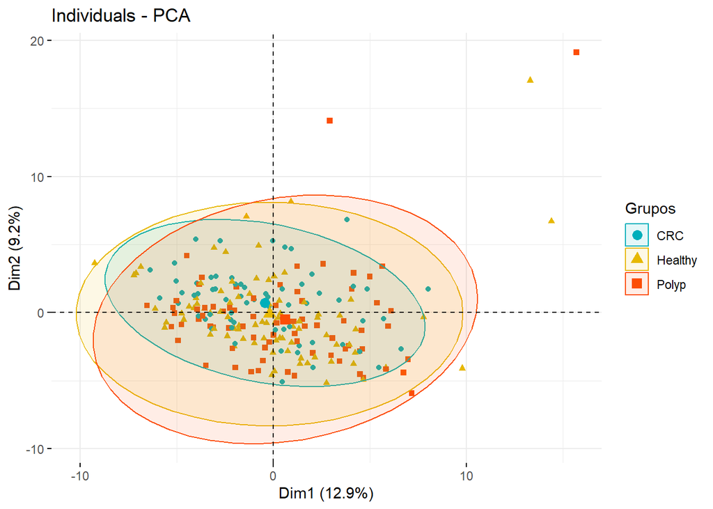

```r
# Gráfico de individuos coloreado por grupo
fviz_pca_ind(pca_result,
             geom.ind = "point",
             col.ind = colData(SE)$Patient_group,
             palette = c("#00AFBB", "#E7B800", "#FC4E07"),
             addEllipses = TRUE,
             legend.title = "Grupos")
```

El gráfico muestra un Análisis de Componentes Principales (PCA) aplicado a individuos de tres grupos: CRC (cáncer colorrectal), Healthy (sanos) y Polyp (pólipos). En el eje horizontal se representa la primera componente principal (Dim1), que explica el 12.9% de la varianza, mientras que en el eje vertical se encuentra la segunda componente principal (Dim2), que explica el 9.2% de la varianza. En conjunto, estas dos dimensiones capturan el 22.1% de la variabilidad total de los datos, lo que sugiere que se requerirían más dimensiones para describir completamente su estructura.

Los puntos representan individuos y están coloreados según su grupo de pertenencia, mientras que las elipses de confianza indican la dispersión de cada grupo. Se observa una superposición considerable entre los tres grupos, lo que sugiere que no existe una separación clara en estas dos dimensiones. Aunque algunos puntos están más alejados del centro, especialmente en los grupos Polyp y Healthy, la mayoría de los individuos se concentran en una región común.

Un mapa de calor es útil para visualizar patrones en las muestras y las características (metabolitos)

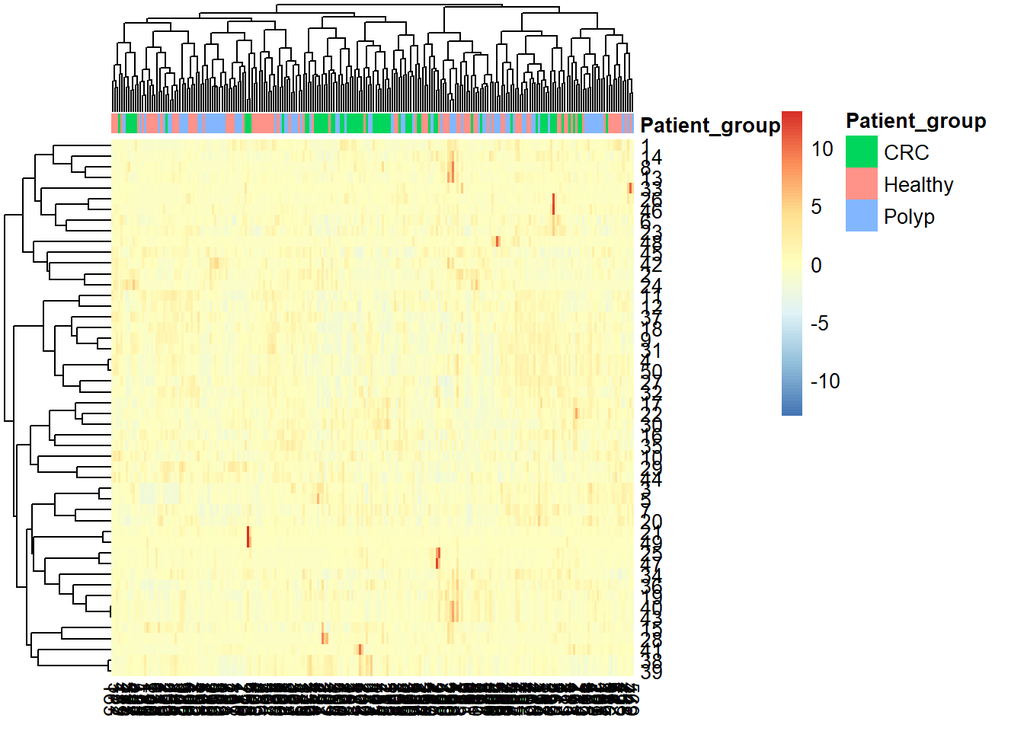

```r
# Heatmap
# Seleccionar los metabolitos más variables
top_var <- head(order(apply(assay(SE), 1, var), decreasing = TRUE), 50)
subset_data <- assay(SE)[top_var,]

# Heatmap
pheatmap(subset_data,
         scale = "row",
         clustering_distance_rows = "correlation",
         clustering_distance_cols = "correlation",
         annotation_col = as.data.frame(colData(SE)[,"Patient_group", drop=FALSE]))
```

El gráfico es un heatmap con clustering jerárquico que representa la expresión de diferentes variables metabolitos en individuos agrupados en tres categorías: CRC (cáncer colorrectal), Healthy (sanos) y Polyp (pólipos). En la parte superior del gráfico, los pacientes están organizados mediante un dendrograma, el cual refleja similitudes en sus perfiles de expresión. Los colores en la barra superior indican la clasificación de cada paciente según su grupo.

La escala de colores del heatmap varía desde azul (valores bajos de expresión) hasta rojo (valores altos de expresión), con la mayoría de los valores en tonos amarillos, lo que sugiere que la mayoría de los datos tienen valores intermedios. Se observan algunas regiones con intensidades rojas dispersas, indicando puntos de expresión elevada en ciertos individuos o características.

El clustering jerárquico no parece mostrar una clara separación de los grupos en función de la expresión, ya que los pacientes de los tres grupos están intercalados en varias ramas del dendrograma. Esto sugiere que los patrones de expresión no presentan una diferenciación fuerte entre CRC, Healthy y Polyp en los primeros niveles de agrupamiento.

```r
# Guardar el objeto SummarizedExperiment
save(SE, file = "SE_analizado.Rda")

# Exportar metadatos
write.csv(colData(SE), file = "metadata.csv")
```